# STA211 : pré-traitement, étude de cas

V. Audigier, N. Niang

17 février, 2025

# 1 Introduction

L’objet de ce document est de montrer comment mettre en oeuvre les méthodes présentées dans la section pré-traitement. Nous appliquerons ces méthodes sur les données *German Credit* à l’aide du logiciel R.

R est un des logiciels libres les plus utilisés par les statisticiens et data-miners en raison de la richesse de ses fonctionnalités. Cette richesse est notamment due à ses librairies (ou packages) proposées par la communauté des utilisateurs. Le logiciel dans sa version de base est un peu austère, il est conseillé de l’utiliser via une interface graphique telle que Rstudio. En particulier, R n’est pas seulement un logiciel, c’est aussi un langage de programmation. L’utilisation d’une interface comme [RStudio](https://www.rstudio.com/products/rstudio/download/#download) facilitera grandement l’écriture de lignes de codes. De nombreuses documentations sur le logiciel sont disponibles sur internet. Parmi elles, l’auditeur pourra consulter :

- https://cran.r-project.org/doc/contrib/Goulet_introduction_programmation_R.pdf : ce libre constitue une bonne introduction au logiciel
- http://duclert.org/ : site référençant les fonctions de base très souvent utilisées en R

Les livres suivants pourront également être lus :

- *Statistique avec R*, 3eme édition Cornillon, P.A., Guyader A., Husson F., Jégou N., Josse J., Kloareg M., Matzner-Løber E., Rouvière L. (2012) Presses Universitaires de Rennes : ce livre fournit à la fois les bases du logiciel et permet de mettre en oeuvre plusieurs dizaines de méthodes statistiques fréquemment utilisées
- *An Introduction to Statistical Learning with Applications in R*, Gareth James, Daniela Witten, Trevor Hastie and Robert Tibshirani (2013), Springer : par rapport au précédent, ce livre permettra de mettre en oeuvre des méthodes plus avancées et plus en phase avec le cours de STA211

Après avoir importé les données à l’aide du logiciel, nous donnerons un aperçu général du jeu données puis développerons la partie exploratoire. A la suite de cette exploration, nous envisagerons différentes façons de prétraiter les données.

NB : Afin de vous approprier le code fourni, **il ne faut pas hésiter à modifier les arguments des fonctions**. Ceci vous permettra d’apprécier le rôle de ces arguments sur les sorties. Vous pouvez également aller consulter les aides des fonctions à la fin desquelles vous trouverez notamment des exemples.

# 2 Importation des données

```r
don <- read.table("https://archive.ics.uci.edu/ml/machine-learning-databases/statlog/german/german.data",
                  sep = " ",
                  stringsAsFactors = TRUE)
```

La commande *str* permet d’avoir un rapide aperçu des données importées

```r
str(don)
```

```
## 'data.frame':    1000 obs. of  21 variables:
##  $ V1 : Factor w/ 4 levels "A11","A12","A13",..: 1 2 4 1 1 4 4 2 4 2 ...
##  $ V2 : int  6 48 12 42 24 36 24 36 12 30 ...
##  $ V3 : Factor w/ 5 levels "A30","A31","A32",..: 5 3 5 3 4 3 3 3 3 5 ...
##  $ V4 : Factor w/ 10 levels "A40","A41","A410",..: 5 5 8 4 1 8 4 2 5 1 ...
##  $ V5 : int  1169 5951 2096 7882 4870 9055 2835 6948 3059 5234 ...
##  $ V6 : Factor w/ 5 levels "A61","A62","A63",..: 5 1 1 1 1 5 3 1 4 1 ...
##  $ V7 : Factor w/ 5 levels "A71","A72","A73",..: 5 3 4 4 3 3 5 3 4 1 ...
##  $ V8 : int  4 2 2 2 3 2 3 2 2 4 ...
##  $ V9 : Factor w/ 4 levels "A91","A92","A93",..: 3 2 3 3 3 3 3 3 1 4 ...
##  $ V10: Factor w/ 3 levels "A101","A102",..: 1 1 1 3 1 1 1 1 1 1 ...
##  $ V11: int  4 2 3 4 4 4 4 2 4 2 ...
##  $ V12: Factor w/ 4 levels "A121","A122",..: 1 1 1 2 4 4 2 3 1 3 ...
##  $ V13: int  67 22 49 45 53 35 53 35 61 28 ...
##  $ V14: Factor w/ 3 levels "A141","A142",..: 3 3 3 3 3 3 3 3 3 3 ...
##  $ V15: Factor w/ 3 levels "A151","A152",..: 2 2 2 3 3 3 2 1 2 2 ...
##  $ V16: int  2 1 1 1 2 1 1 1 1 2 ...
##  $ V17: Factor w/ 4 levels "A171","A172",..: 3 3 2 3 3 2 3 4 2 4 ...
##  $ V18: int  1 1 2 2 2 2 1 1 1 1 ...
##  $ V19: Factor w/ 2 levels "A191","A192": 2 1 1 1 1 2 1 2 1 1 ...
##  $ V20: Factor w/ 2 levels "A201","A202": 1 1 1 1 1 1 1 1 1 1 ...
##  $ V21: int  1 2 1 1 2 1 1 1 1 2 ...
```

On constate que les noms des variables, comme ceux de leurs modalités (pour les variables qualitatives) ne sont pas du tout explicites. Ceci rend l’interprétation très difficile. Pour y remédier, on renomme les différentes variables et les modalités selon le descriptif des données (disponible [ici](https://archive.ics.uci.edu/ml/machine-learning-databases/statlog/german/german.doc)).

```r
# Modification des noms des variables
colnames(don)<-c(
  "Status",
  "Duration",
  "History",
  "Purpose",
  "Credit.Amount",
  "Savings account/bonds",
  "Length.of.current.employment",
  "Instalment.per.cent",
  "Sex.Marital.Status",
  "Guarantors",
  "Duration.in.Current.address",
  "Property",
  "Age.years",
  "Other.installment.plans",
  "Housing",
  "No.of.Credits.at.this.Bank",
  "Job",
  "No.of.dependents"
  ,"Telephone",
 "Foreign.Worker",
 "Creditability")


# Modification des noms des modalités des variables qualitatives
levels(don$Status) <- c("lt.0", "0.to.200", "gt.200", "none")

levels(don$History) <-
  c("noCredit.allPaid",
    "thisBank.AllPaid",
    "paidDuly",
    "delay",
    "critical")

levels(don$Purpose) <-
  c(
    "NewCar",
    "UsedCar",
    "Other",
    "Furniture.Equipment",
    "Radio.Television",
    "DomesticAppliance",
    "Repairs",
    "Education",
    "Retraining",
    "Business"
  )

levels(don$`Savings account/bonds`) <-
  c("lt.100", "100.to.500", "500.to.1000", "gt.1000", "Unknown")

levels(don$Length.of.current.employment) <-
  c("lt.1", "1.to.4", "4.to.7", "gt.7", "Unemployed")

levels(don$Sex.Marital.Status) <-
  c(
    "Male.Divorced.Seperated",
    "Female.NotSingle",
    "Male.Single",
    "Male.Married.Widowed"
  )

levels(don$Guarantors) <- c("None", "CoApplicant", "Guarantor")

levels(don$Property) <-
  c("RealEstate", "Insurance", "CarOther", "Unknown")

levels(don$Other.installment.plans) <- c("Bank", "Stores", "None")

levels(don$Housing) <- c("Rent", "Own", "ForFree")

levels(don$Job) <-
  c(
    "UnemployedUnskilled",
    "UnskilledResident",
    "SkilledEmployee",
    "Management.SelfEmp.HighlyQualified"
  )

levels(don$Foreign.Worker) <- c("yes", "no")

levels(don$Telephone) <- c("none", "yes")
```

On modifie également le type de certaines variables. En effet, R interprête les types de variables pour proposer des analyses statistiques adaptées. Par exemple, si une variable est de type *factor*, un appel à la fonction *lm* (permettant de construire un modèle de régression) où cette variable serait une variable explicative amènera à considérer un coefficient de régression pour chacune de ses modalités, là où un seul coefficient serait considéré si la variable était de type *numeric*.

```r
#Codage des variables quantitatives en type "numeric" (plutot que "integer")

##pour la variable Duration
don$Duration <- as.numeric(don$Duration)
class(don$Duration)

## pour les variables Credits.Amount et Age.years
don$Credit.Amount <- as.numeric(don$Credit.Amount)
don$Age.years <- as.numeric(don$Age.years)

#Codage de la variable réponse en type "factor"
don$Creditability <- as.factor(don[, "Creditability"])
levels(don$Creditability) <- c("good", "bad")
```

# 3 Aperçu général

```r
#nombre d'individus et variables
dim(don)
```

```
## [1] 1000   21
```

```r
#nature des variables
table(sapply(don, class))
```

```
##
##  factor integer numeric
##      14       4       3
```

```r
#variables qualitatives
var.factor <- which(sapply(don, class)=="factor")
names(var.factor)
```

```
##  [1] "Status"                       "History"
##  [3] "Purpose"                      "Savings account/bonds"
##  [5] "Length.of.current.employment" "Sex.Marital.Status"
##  [7] "Guarantors"                   "Property"
##  [9] "Other.installment.plans"      "Housing"
## [11] "Job"                          "Telephone"
## [13] "Foreign.Worker"               "Creditability"
```

```r
#variables quantitatives
var.numeric <- which(sapply(don, class)=="numeric"|sapply(don, class)=="integer")
names(var.numeric)
```

```
## [1] "Duration"                    "Credit.Amount"
## [3] "Instalment.per.cent"         "Duration.in.Current.address"
## [5] "Age.years"                   "No.of.Credits.at.this.Bank"
## [7] "No.of.dependents"
```

```r
#nombre de données manquantes
sum(is.na(don))
```

```
## [1] 0
```

# 4 Exploration

## 4.1 Analyse univariée

### 4.1.1 Variables quantitatives

#### 4.1.1.1 Indicateurs statistiques

```r
# installation du package stargazer
install.packages("stargazer")

# chargement de la librarie
library(stargazer)

# affichage de quelques indicateurs statistiques pour variables quantitatives
stargazer(don,
          summary.stat = c("n", "min", "p25", "median", "mean", "p75", "max", "sd"),
          type = "text")
```

| Statistic | N | Min | Pctl(25) | Median | Mean | Pctl(75) | Max | St. Dev. |
| --- | --- | --- | --- | --- | --- | --- | --- | --- |
| Duration | 1,000 | 4 | 12 | 18 | 20.903 | 24 | 72 | 12.059 |
| Credit.Amount | 1,000 | 250 | 1,365.5 | 2,319.5 | 3,271.258 | 3,972.2 | 18,424 | 2,822.737 |
| Instalment.per.cent | 1,000 | 1 | 2 | 3 | 2.973 | 4 | 4 | 1.119 |
| Duration.in.Current.address | 1,000 | 1 | 2 | 3 | 2.845 | 4 | 4 | 1.104 |
| Age.years | 1,000 | 19 | 27 | 33 | 35.546 | 42 | 75 | 11.375 |
| No.of.Credits.at.this.Bank | 1,000 | 1 | 1 | 1 | 1.407 | 2 | 4 | 0.578 |
| No.of.dependents | 1,000 | 1 | 1 | 1 | 1.155 | 1 | 2 | 0.362 |

On peut remarquer qu’aucune des variables n’est constante. De telles variables n’auraient en effet aucun intérêt pour l’analyse.

#### 4.1.1.2 Représentations graphiques

On commence par visualiser les distributions marginales des variables via des diagrammes en barres et des histogrammes. Les variables *Duration*, *Credit.Amount* et *Age.years* ayant un grand nombre de valeurs distinctes, on les représentera via des histogrammes.

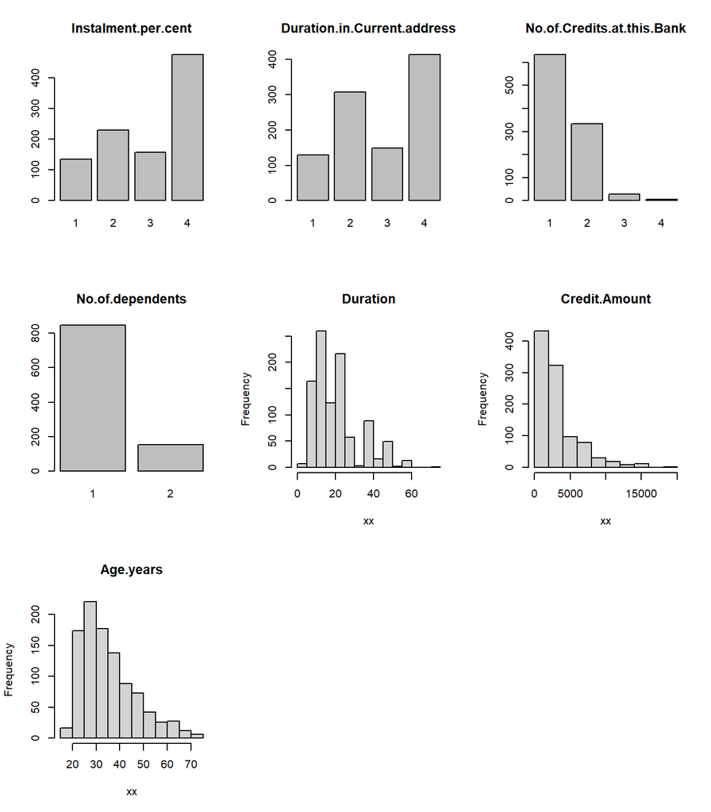

```r
#diagrammes en barres
varbarplot <- c("Instalment.per.cent", "Duration.in.Current.address", "No.of.Credits.at.this.Bank", "No.of.dependents")

mapply(don[,varbarplot],
       FUN = function(xx,name){barplot(table(xx), main = name)},
       name = varbarplot)

#histogrammes
varhist <- c("Duration", "Credit.Amount", "Age.years")
mapply(don[,varhist],
       FUN = function(xx,name){hist(xx, main = name)},
       name = varhist)
```

On identifie clairement une queue à droite sur les variables *Duration*, *Credit Amount* et *Age*. Une transformation logarithmique pourrait permettre de rendre ces distributions symétriques.

On repère ensuite les potentielles valeurs aberrantes par les boîtes à moustaches.

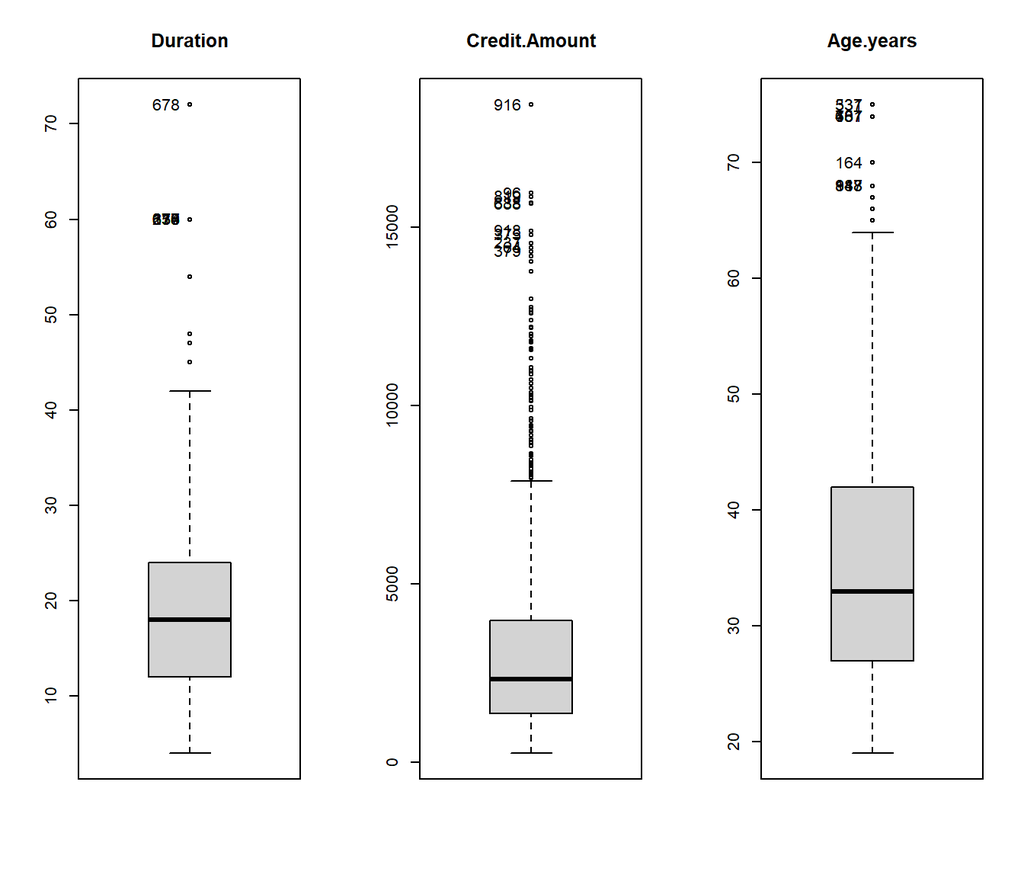

```r
library(car)
mapply(don[,varhist],
       FUN = function(xx,name){Boxplot(xx, main = name, id.n = 2, ylab="")},
       name = varhist)
```

Bien que différentes valeurs semblent relativement élevées, il est difficile de prendre dès à présent la décision de gérer ces valeurs (par exemple en les considérant comme manquantes et en les imputant). Ce choix pourra être fait a posteriori si nécessaire.

### 4.1.2 Variables qualitatives

On repère des modalités rares via les diagrammes en barres (on pourrait de façon équivalente visualiser cette information sous forme de tableaux)

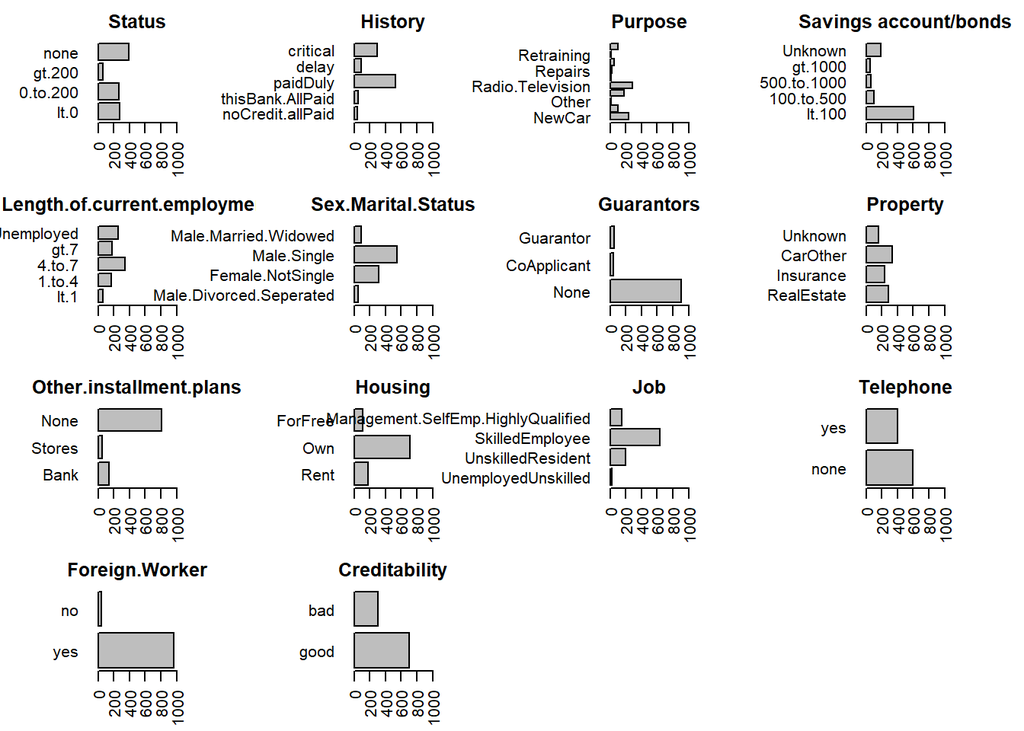

```r
mapply(don[,var.factor],
       FUN = function(xx,name){barplot(table(xx),
                                       main = name,
                                       horiz = TRUE,
                                       las = 2,
                                       xlim = c(0,1000))},
       name = names(var.factor))
```

En fonction de la distribution de la variable réponse au sein de chaque modalité définie par ces variables, il pourra pertinent ou non d’effectuer certains regroupements. On aura besoin pour cela d’effectuer une analyse bivariée.

## 4.2 Analyse bivariée

Etant dans un cas de classification supervisée, nous distinguons l’analyse bivariée des couples mettant en jeu la variable réponse, de celle des couples ne portant que sur des variables explicatives.

### 4.2.1 Lien entre variables explicatives et variable réponse

#### 4.2.1.1 Linéarité

Afin d’identifier la nature du lien entre les variables quantitatives et la réponse, on représente la proportion de bons payeurs en fonction des variables quantitatives. Ce type d’analyse dans le cas d’une variable explicative continue nécessitera d’effectuer une discrétisation.

On commence par identifier le lien entre la variable *Creditability* et la variable *Duration*.

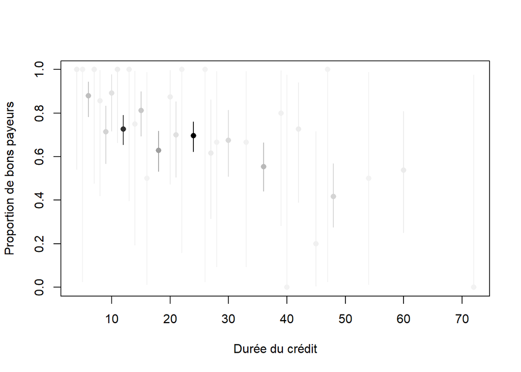

```r
# calcul de la proportion de bons payeurs pour chaque valeur de la durée de credit
cont.table <- table(don$Duration,don$Creditability)
prof.lignes <- prop.table(cont.table, 1)

#calcul des bornes de l'intervalle de confiance associée
res.binom.test <- mapply(cont.table[, 1],
                       FUN = binom.test,
                       n = rowSums(cont.table),
                       SIMPLIFY = FALSE)
ci<-sapply(res.binom.test, "[[", "conf.int")

# représentation des proportions en fonction de la durée de crédit
# (coloration en fonction du nombre d'observations pour la durée considérée)
abscisses <- as.numeric(rownames(prof.lignes))
col <- gray.colors(184,.95,0)[rowSums(cont.table)]

# affichage des proportions
plot(abscisses,
     prof.lignes[,1],
     pch = 16,
     col = col,
     xlab = "Durée du crédit",
     ylab = "Proportion de bons payeurs")

# affichage des intervalles de confiance
for(ii in 1:length(abscisses)){
  segments(x0 = abscisses[ii],
           y0 = ci[1,ii],
           x1 = abscisses[ii],
           y1 = ci[2,ii],
           col = col[ii])
}
```

Sur ce graphique, un point est d’autant plus noir que le nombre d’individus utilisés pour déterminer la proportion correspondante est grande. Les points les plus noirs sont donc ceux avec les intervalles de confiance les plus courts. On constate que la proportion de bons payeurs décroît de façon relativement linéaire avec la durée du Crédit.

On effectue la même opération pour la variable *Age* en effectuant au préalable une discrétisation en 20 classes.

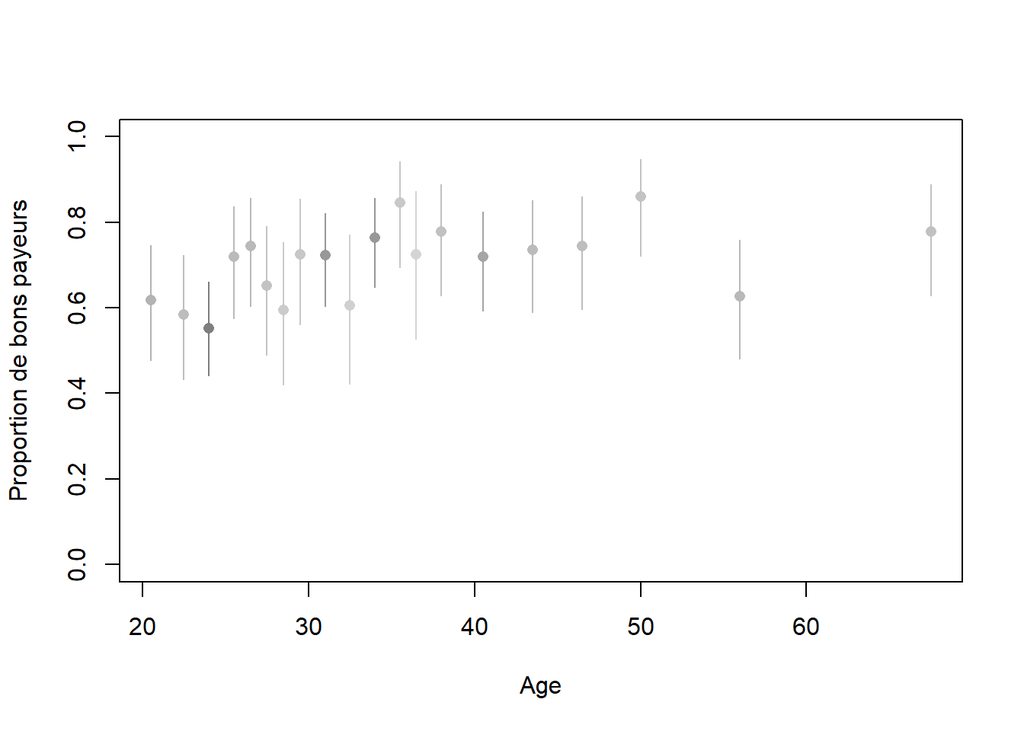

```r
ordrequantiles <- seq(0, 1, 1/20)
Age.years.new <- cut(don$Age.years,
                     breaks = quantile(don$Age.years, probs = ordrequantiles))


cont.table <- table(Age.years.new,don$Creditability)
prof.lignes <- prop.table(cont.table, 1)
res.binom.test <- mapply(cont.table[,1],
                       FUN = binom.test,
                       n = rowSums(cont.table),
                       SIMPLIFY = FALSE)
ci <- sapply(res.binom.test, "[[", "conf.int")
abscisses <- hist(don$Age.years, quantile(don$Age.years,probs =ordrequantiles), plot = FALSE)$mids
col <- gray.colors(112,.95,0)[rowSums(cont.table)]


plot(abscisses,
     prof.lignes[,1],
     pch = 16,
     col = col,
     xlab = "Age",
     ylab = "Proportion de bons payeurs",
     ylim = c(0, 1))

for(ii in 1:length(abscisses)){
  segments(x0 = abscisses[ii],
           y0 = ci[1,ii],
           x1 = abscisses[ii],
           y1 = ci[2,ii],
           col = col[ii])
}
```

On voit que la liaison est plutôt non-monotone. On pourra découper la variable Age en 3 classes pour gérer cette non-linéarité (résultat en figure [5.1](https://par.moodle.lecnam.net/pluginfile.php/1819921/mod_label/intro/etude_cas.html?time=1739808160383#fig:figdecage3)).

On visualise enfin le lien avec les autres variables quantitatives (discrètes avec peu de modalités)

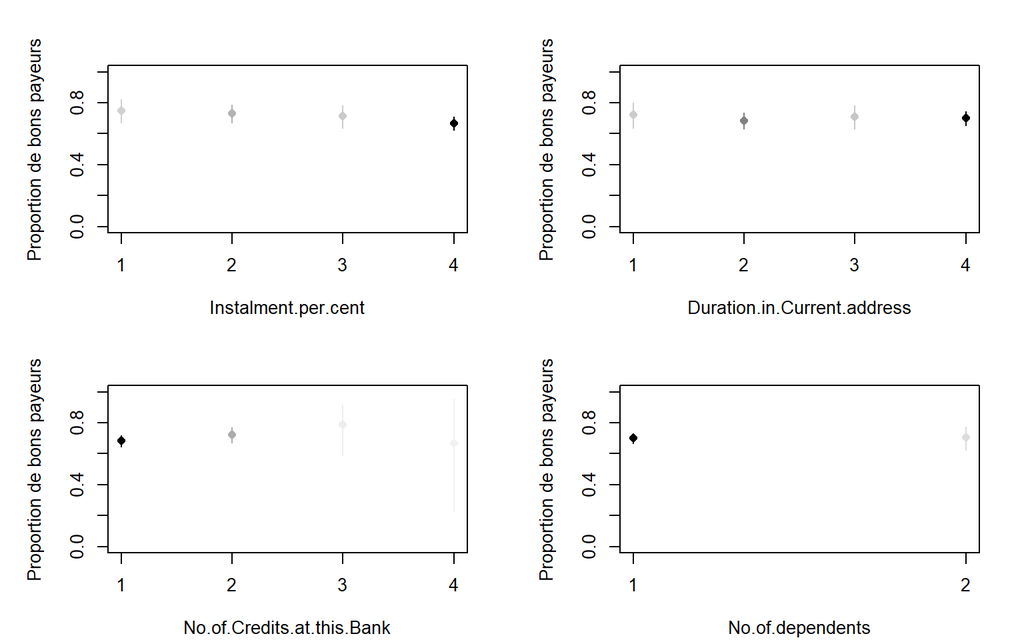

```r
par(mfrow=c(2,2),mar=c(4,5, 3, 2) + 0.1)

for(ii in c("Instalment.per.cent", "Duration.in.Current.address", "No.of.Credits.at.this.Bank", "No.of.dependents")){
  xx <- don[,ii]
  cont.table <- table(cbind.data.frame(xx,don$Creditability))
  prof.lignes <- prop.table(cont.table,1)
  res.binom.test <- mapply(cont.table[,1],
                         FUN=binom.test,
                         n=rowSums(cont.table),
                         SIMPLIFY = FALSE)
  ci <- sapply(res.binom.test,"[[","conf.int")

  #graphique pour la variable courante
  abscisses <- as.numeric(rownames(prof.lignes))
  col <- gray.colors(max(rowSums(cont.table)),.95,0)[rowSums(cont.table)]
  plot(x = abscisses,
       y=prof.lignes[,1],
       pch=16,
       col=col,
       ylab="Proportion de bons payeurs",
       xlab=ii,
       xaxt="n",
       ylim=c(0,1))
  axis(side=1,at = abscisses,labels = abscisses,xlab=varbarplot[ii])
  for(ii in 1:length(abscisses)){
    segments(x0=abscisses[ii],
             y0=ci[1,ii],
             x1=abscisses[ii],
             y1=ci[2,ii],
             col=col[ii])
  }
}
```

#### 4.2.1.2 Identification des variables les plus discriminantes

On regarde ensuite quelles sont les variables les plus liées au statut bon/mauvais payeur.

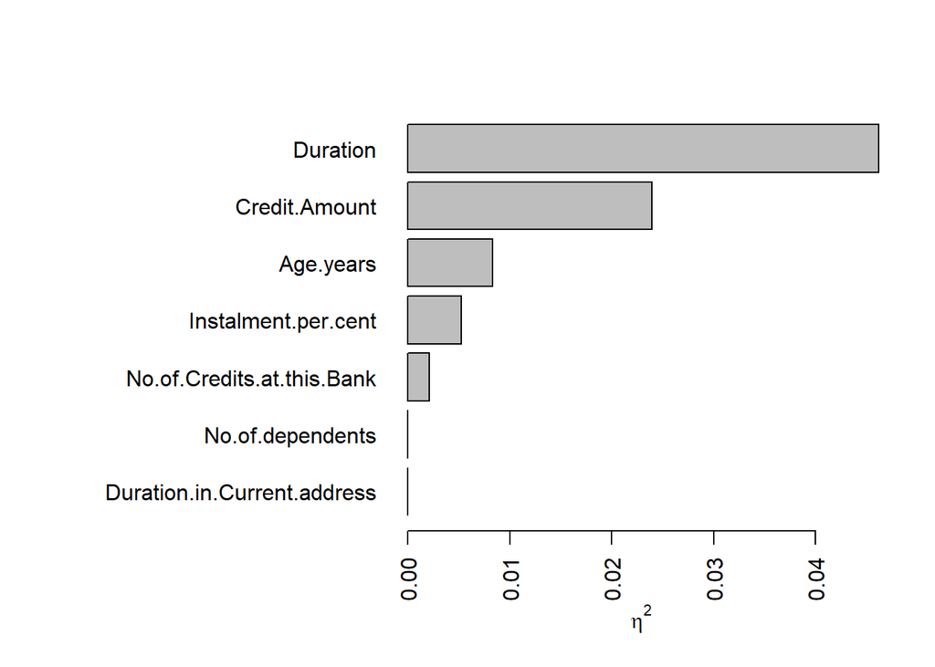

```r
#Chargement du package BioStatR
install.packages("BioStatR")
library(BioStatR)

#calcul des rapport de corrélation
res.eta2 <- sapply(don[,var.numeric], eta2 ,y = don$Creditability)

#tri par valeurs décroissantes
res.eta2 <- sort(res.eta2)

#représentation
par(mar = c(5, 15, 4, 2) + 0.1, mfrow = c(1,1))#pour gérer les marges du graphique
barplot(res.eta2, horiz = TRUE, las = 2, xlab = expression(eta^2))
```

Parmi les variables quantitatives, les liaisons les plus fortes sont observées pour les variables *Duration* et *Credit Amount*. Au contraire, les variables *No.of.dependents* et *Duration in Current address* n’apparaissent pas comme discriminantes.

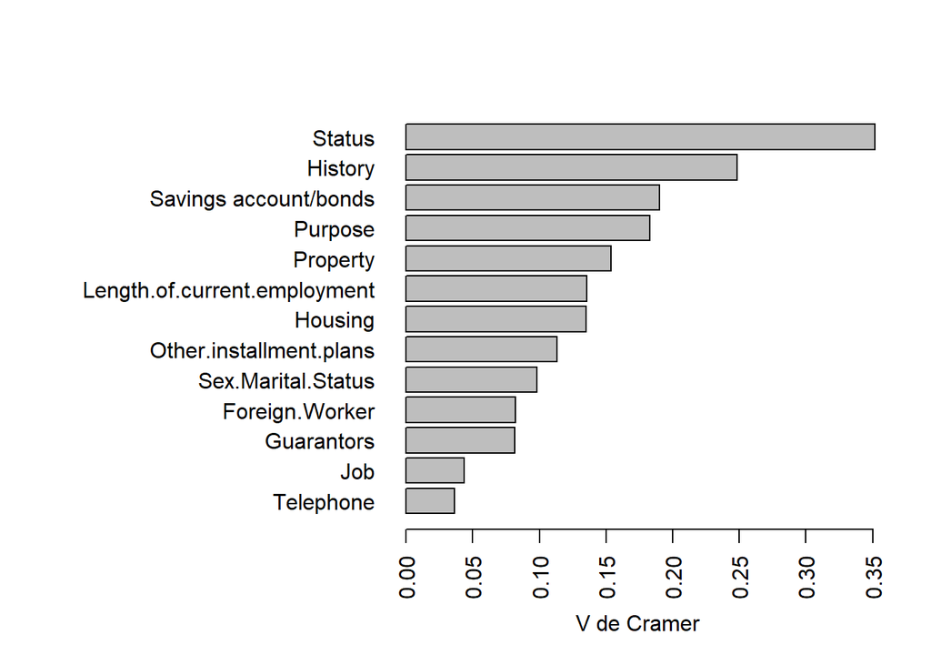

```r
#Creation d'une matrice contenant les variables qualitatives et quantitatives discrètes (sans la variable Creditability)
don.cramer <- don[,c(var.factor)]
don.cramer <- don.cramer[,-which(colnames(don.cramer)=="Creditability")]

#calcul du V de cramer entre Creditability et les autres variables non continues de don.cramer
library(DescTools)
res.cramer <- sapply(don.cramer,
                   FUN = function(xx,yy){CramerV(table(xx,yy))},
                   yy = don$Creditability)

#tri par valeurs décroissantes
res.cramer <- sort(res.cramer)

#représentation
par(mar=c(5, 15, 4, 2) + 0.1)
barplot(res.cramer, horiz = TRUE, las = 2, xlab = "V de Cramer")
```

Parmi les variables qualitatives, les variables les plus liées sont *Status* et *History*, tandis que les variables *Job* et *Telephone* ne semblent pas discriminantes.

Ces analyses pourront être utiles en vue d’une réduction du nombre de colonnes, les variables les moins discriminantes seront a priori amenées à être écartées en priorité. Attention toutefois car on a évalué ici un lien direct entre les variables explicatives et la réponse, il est possible que la liaison soit plus complexe, mettant en jeu des liaisons de type interaction par exemple. Pour les détecter, on pourrait utiliser une régression logistique ou des arbres binaires (cf Tufféry (2007)).

On pourra tester le caractère significatif des liaisons entre la variable réponse qualitative en utilisant la fonction *catdes* du package *FactoMineR* permettant de décrire une partition (ici selon les modalités *good* et *bad* de la variable réponse) à partir des variables quantitatives, et des modalités des variables qualitatives (voir Lebart, Morineau, and Piron (2006) pour la méthode et le [site du package](http://factominer.free.fr/factomethods/categories-description.html) pour la lecture des sorties de la fonction). Notons néanmoins que ceci n’est pertinent que si le nombre d’observations est modéré, sans quoi toutes les variables risqueraient d’être considérées comme statistiquement reliées à la variable réponse. Par ailleurs, pour éviter les hypothèses paramétriques, il pourra être préférable d’utiliser des intervalles de confiance bootstrap (Lejeune (2010)).

```r
# installation et chargement du package FactoMineR
install.packages("FactoMineR")
library(FactoMineR)
catdes(don, num.var = ncol(don))
```

#### 4.2.1.3 Allure des distributions conditionnelles

La distribution des variables continues conditionnellement à la variable réponse est parfois déterminante pour l’utilisation de certains modèles, notamment l’analyse linéaire discriminante. On analyse donc la nature de ces distributions.

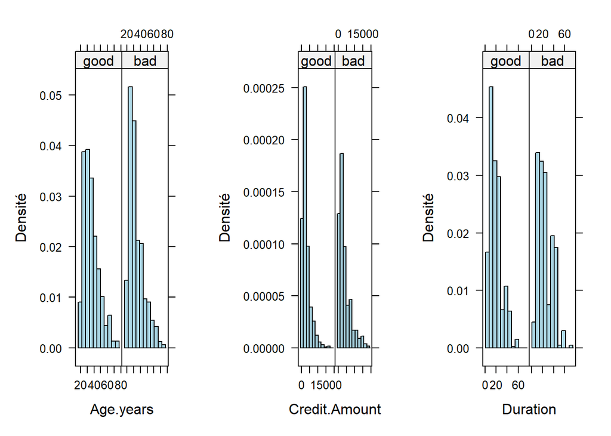

```r
# Chargement de la librarie lattice permettant de faire des graphiques relativement avancés
# et de la librairie gridExra, utilisée ici pour positionner les graphiques les uns à côté des autres

library(lattice);library(gridExtra)

# distribution conditionnelle de Age.Years
plot1 <- lattice::histogram(~Age.years|Creditability,
                            data = don,
                            type = "density",
                            col = "lightblue",
                            ylab = "Densité")
# distribution conditionnelle de Credit.Amount
plot2 <- lattice::histogram(~Credit.Amount|Creditability,
                            data = don,
                            type = "density",
                            col = "lightblue",
                            ylab ="Densité")
# distribution conditionnelle de Duration
plot3 <- lattice::histogram(~Duration|Creditability,
                            data = don,
                            type = "density",
                            col = "lightblue",
                            ylab = "Densité")

# affichage
grid.arrange(plot1, plot2, plot3, nrow =1, ncol = 3)
```

Clairement, les distributions conditionnelles des variables *Age*, *Credit Amont* et *Duration* ne sont pas normales. Peut-être sera-t-il nécessaire de transformer ces variables par la suite si cette normalité était requise par les méthodes employées. Notons qu’il est aussi possible de comparer certains indicateurs statistiques entre les deux groupes

```r
by(don[,-ncol(don)],
   INDICES = don$Creditability,
   FUN = stargazer,
   summary.stat = c("n", "min", "p25", "median", "mean", "p75", "max", "sd"),
   type = "text")
```

| Statistic | N | Min | Pctl(25) | Median | Mean | Pctl(75) | Max | St. Dev. |
| --- | --- | --- | --- | --- | --- | --- | --- | --- |
| Duration | 700 | 4 | 12 | 18 | 19.207 | 24 | 60 | 11.080 |
| Credit.Amount | 700 | 250 | 1,375.5 | 2,244 | 2,985.457 | 3,634.8 | 15,857 | 2,401.472 |
| Instalment.per.cent | 700 | 1 | 2 | 3 | 2.920 | 4 | 4 | 1.128 |
| Duration.in.Current.address | 700 | 1 | 2 | 3 | 2.843 | 4 | 4 | 1.108 |
| Age.years | 700 | 19 | 27 | 34 | 36.224 | 42.2 | 75 | 11.381 |
| No.of.Credits.at.this.Bank | 700 | 1 | 1 | 1 | 1.424 | 2 | 4 | 0.585 |
| No.of.dependents | 700 | 1 | 1 | 1 | 1.156 | 1 | 2 | 0.363 |

| Statistic | N | Min | Pctl(25) | Median | Mean | Pctl(75) | Max | St. Dev. |
| --- | --- | --- | --- | --- | --- | --- | --- | --- |
| Duration | 300 | 6 | 12 | 24 | 24.860 | 36 | 72 | 13.283 |
| Credit.Amount | 300 | 433 | 1,352.5 | 2,574.5 | 3,938.127 | 5,141.5 | 18,424 | 3,535.819 |
| Instalment.per.cent | 300 | 1 | 2 | 4 | 3.097 | 4 | 4 | 1.088 |
| Duration.in.Current.address | 300 | 1 | 2 | 3 | 2.850 | 4 | 4 | 1.095 |
| Age.years | 300 | 19 | 25 | 31 | 33.963 | 40 | 74 | 11.222 |
| No.of.Credits.at.this.Bank | 300 | 1 | 1 | 1 | 1.367 | 2 | 4 | 0.560 |
| No.of.dependents | 300 | 1 | 1 | 1 | 1.153 | 1 | 2 | 0.361 |

Pour les variables qualitatives, il sera intéressant d’identifier la distribution conditionnelle de la variable réponse en fonction des modalités des variables. Ceci permettra d’effectuer des regroupements de modalités préservant au mieux les liaisons entre ces variables et la variable réponse. On choisit donc de représenter la proportion de bons payeurs en fonction des modalités des différentes variables explicatives qualitatives.

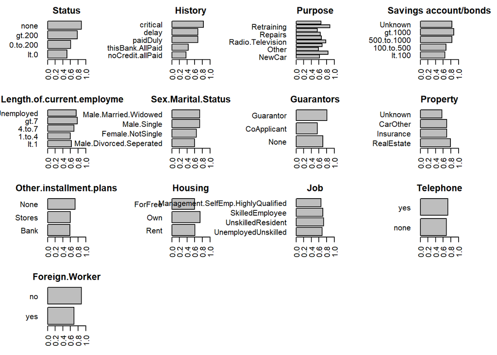

```r
var.expl.quali <- names(var.factor[-length(var.factor)])
mapply(don[,var.expl.quali], FUN = function(xx,name){
  tmp <- table(xx,don$Creditability)
  tmp <- tmp/rowSums(tmp)
  barplot(tmp[,"good"], main = name, horiz = TRUE, las = 2, xlim = c(0,1))
}, name = var.expl.quali)
```

Par exemple, on voit que la proportion de bons payeurs est sensiblement la même que le client prenne la modalité *thisBank.AllPaid* ou *noCredit.allPaid* de la variable *History*. Ces deux modalités étant rares (cf Section [4.1.2](https://par.moodle.lecnam.net/pluginfile.php/1819921/mod_label/intro/etude_cas.html?time=1739808160383#qualiuniv)), on pourra les fusionner si cela est nécessaire pour les méthodes d’analyse employées.

### 4.2.2 Lien entre variables explicatives

Des liaisons trop fortes entre variables explicatives peuvent conduire à de grande instabilité dans les modèles. L’analyse des liaisons entre variables explicatives permettra de détecter les couples de variables les plus liées.

#### 4.2.2.1 Variables quantitatives

On détermine les valeurs des coefficients de corrélation linéaire et de Spearman entre les variables quantitatives.

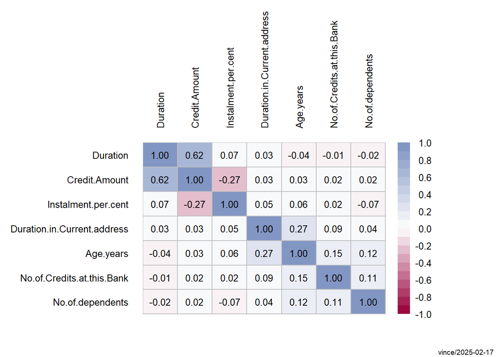

```r
matcor <- cor(don[, var.numeric])
PlotCorr(matcor, mar = c(3, 10, 10, 8))
text(x = rep(1:ncol(matcor), ncol(matcor)),
     y = rep(1:ncol(matcor), each = ncol(matcor)),
     label = sprintf("%0.2f", matcor[,ncol(matcor):1]),
     cex = 0.8,
     xpd = TRUE)
```

```r
matcor <- cor(don[,var.numeric],method = "spearman")
PlotCorr(matcor, mar = c(3, 10, 10, 8))
text(x = rep(1:ncol(matcor), ncol(matcor)),
     y = rep(1:ncol(matcor), each = ncol(matcor)),
     label = sprintf("%0.2f", matcor[, ncol(matcor):1]),
     cex = 0.8,
     xpd = TRUE)
```

[output not shown]